# Impact of a malaria elimination on school outcomes

August 3, 2017

# Introduction

## Context

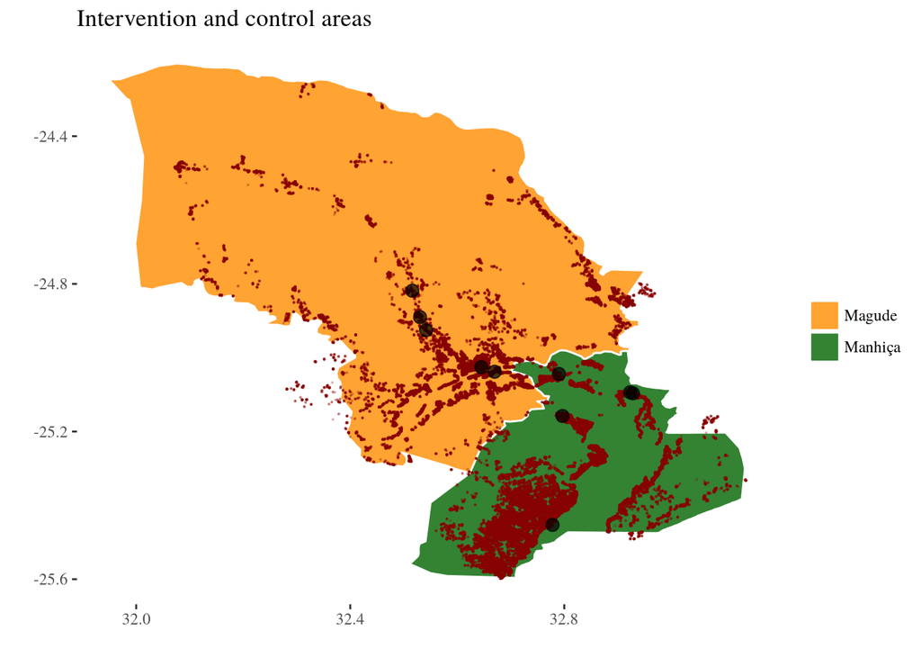

## Literature

This is the first reference we do have [1]

# Methods

## Data cleaning

We used Monte Carlo simulations to determine the likelihood of uninterrupted “chains” of presences and absences, and removed those which exceeded a likelihood of 0.1%.

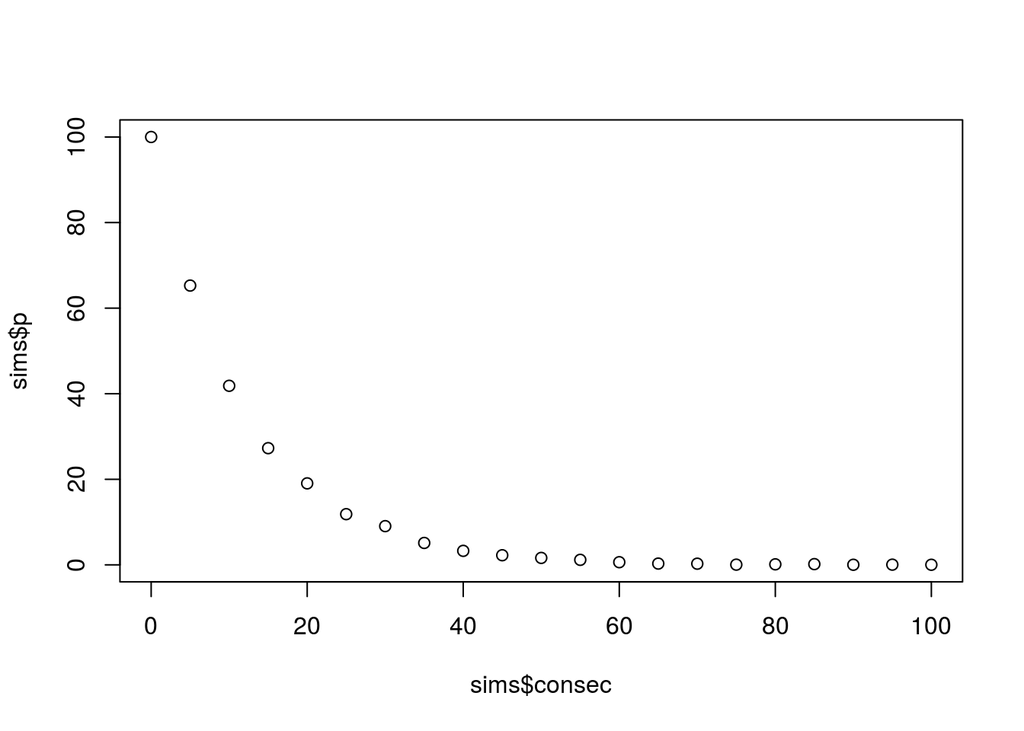

## Analysis

### Difference in differences

In diff-diff models: assumption: parallel trends (in the outcome variable) in treatment and control groups before the introduction of the intervention

### Event study model

The coefficients for the interaction between trimester and intervention area identify the differential trends in the outcome variable over time between the treated and control regions. Thus, as the policy is implemented in 2016, these coefficients identify any differential pre-trends in the outcome variable between treated and control regions (the crucial assumption for diff-diff models).

# Results

## Descriptive

The districts are similar.

| Characteristic | Manhiça | Magude |
| --- | --- | --- |
| Age mean | 9.37 | 9.16 |
| age SD | 2.71 | 2.78 |
| conditions score SD | 3986.16 | 4150.42 |
| Education mean | 2.38 | 2.53 |
| education SD | 1.16 | 1.46 |
| Females | 2352.00 | 750.00 |
| Males | 2445.00 | 708.00 |
| N | 6191.00 | 2612.00 |
| Ses asset score mean | 6976.67 | 6752.86 |
| ses asset score SD | 971.98 | 805.78 |
| Siblings mean | 4.49 | 4.40 |
| siblings SD | 2.53 | 2.84 |

|  | District | Year | Absenteeism rate | Average grade |
| --- | --- | --- | --- | --- |
| 1 | Magude | 2015 | 11.03 | 12.15 |
| 2 | Magude | 2016 | 8.92 | 12.51 |
| 3 | Manhiça | 2015 | 8.91 | 12.28 |
| 4 | Manhiça | 2016 | 8.53 | 12.46 |

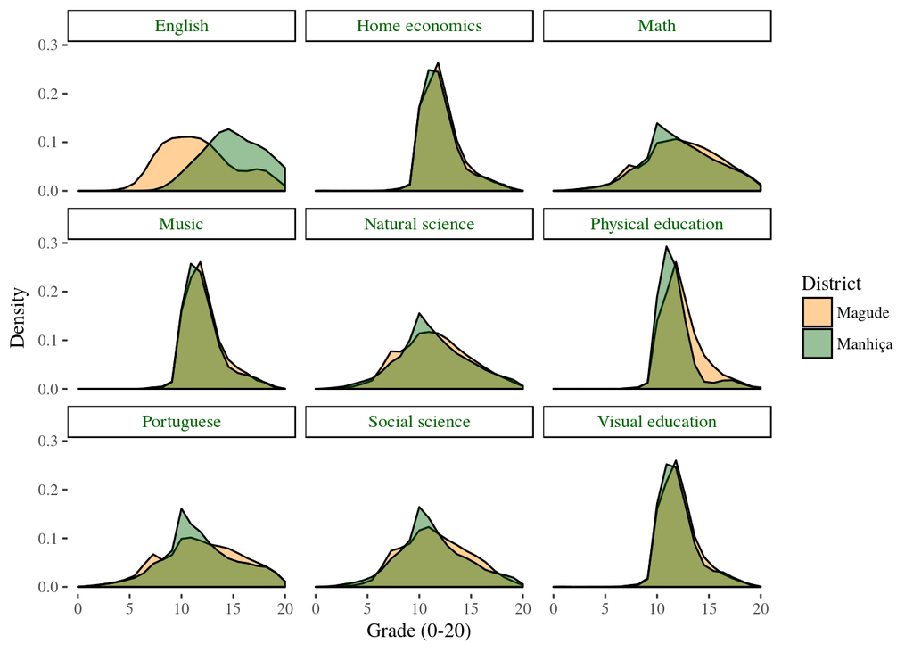

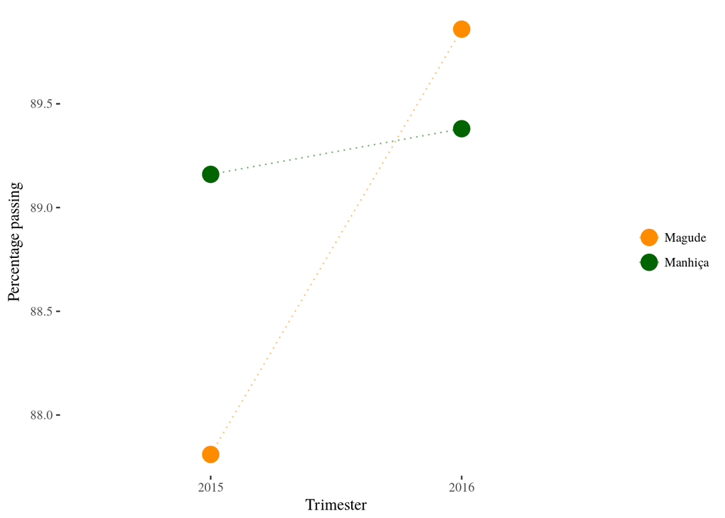

Mean grade obtained, all subjects

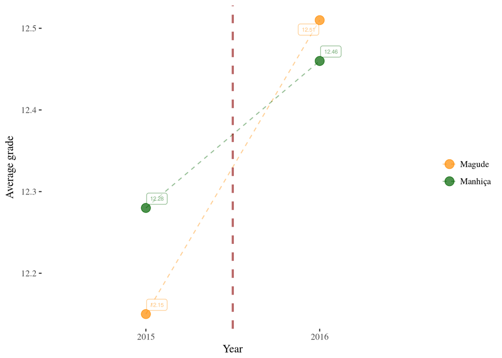

## Analytical

| Term | Key | 1 | 2 | 3 |
| --- | --- | --- | --- | --- |
| After | Estimate | 0.004 | 0.004 | 0.004 |
|  | P | 0.021 | 0.004 | 0.004 |
|  | S.E. | 0.002 | 0.001 | 0.001 |
| After:Intervention | Estimate | 0.016 | 0.017 | 0.017 |
|  | P | < 0.001 | < 0.001 | < 0.001 |
|  | S.E. | 0.003 | 0.003 | 0.003 |
| (Intercept) | Estimate | 0.867 | 0.754 | 0.755 |
|  | P | < 0.001 | < 0.001 | < 0.001 |
|  | S.E. | 0.002 | 0.026 | 0.026 |
| Intervention | Estimate | 0.047 | 0.039 | 0.039 |
|  | P | < 0.001 | < 0.001 | < 0.001 |
|  | S.E. | 0.005 | 0.005 | 0.005 |

### Performance

Here are density curves by subject.

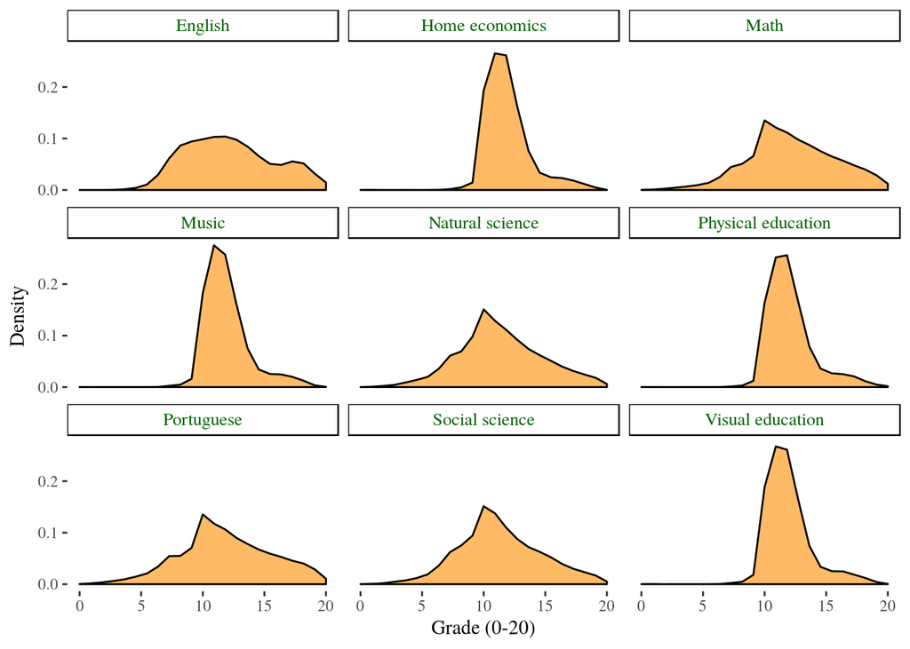

### Absenteeism

Below shows absenteeism for each school.

Average absenteeism rate, per term, per school

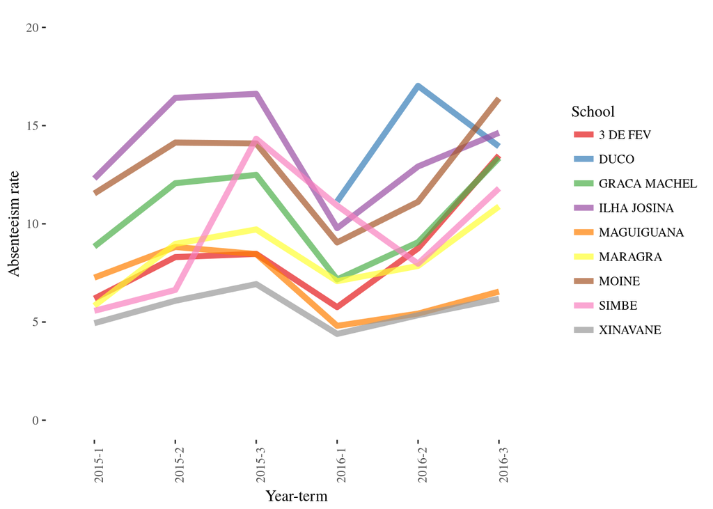

Below shows absenteeism at the district level.

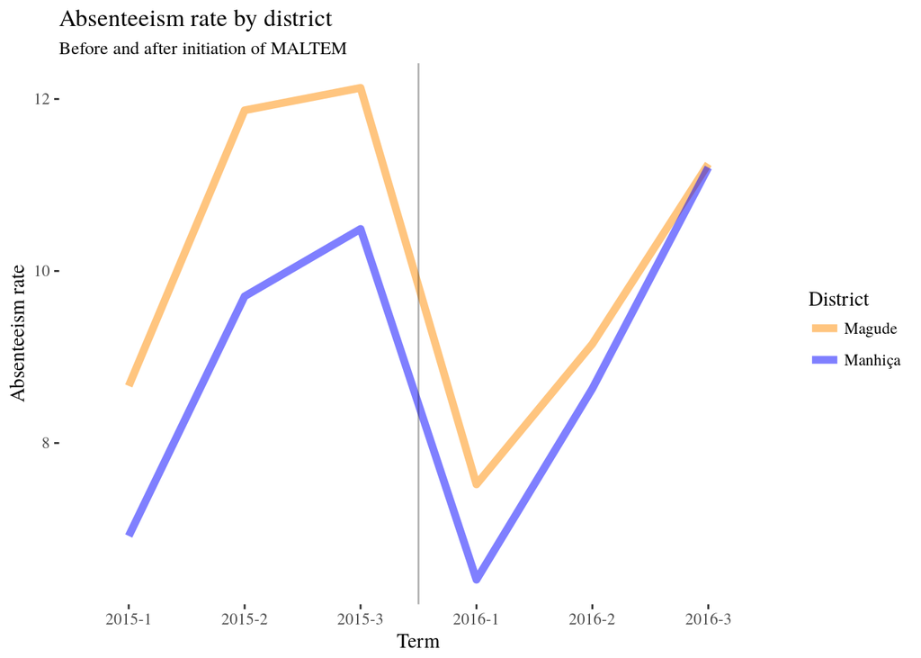

If we aggregate at the year level….

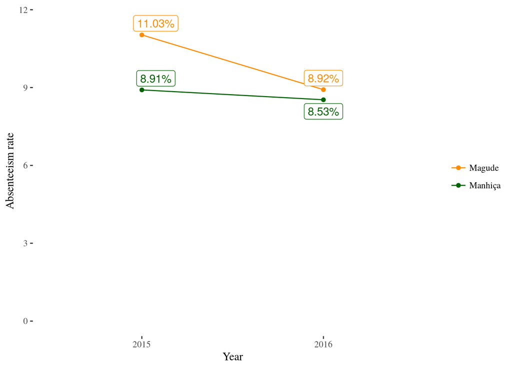

# Discussion

# References

1. Grant M, Lloyd C, Mensch B. Menstruation and school absenteeism: Evidence from rural malawi. Comparative Education Review. University of Chicago Press; 2013;57: 260–284. doi:10.1086/669121